# *DEprot*: R-package for LFQ proteomics data normalization, imputation and Differential Expression analyses

### 6.4.3 Visualize DE analyses

#### 6.4.3.1 P-values distributions

Good practice is to visualize the distribution of the p-values and compare it with the adjusted ones in order to estimate the quality of the statistical tools used. In the histograms, the horizontal dashed line indicates the median of the frequency, while the vertical dotted line demarcates the P-value threshold used for the differential analyses.  
This can be performed using the `check.pvalues` function:

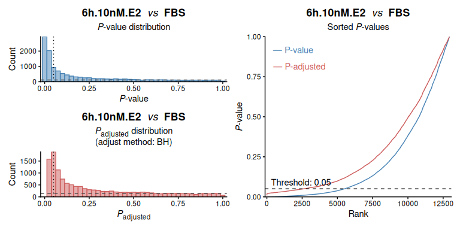

```r
pval.distribution <- check.pvalues(DEprot.analyses.object = dpo_analyses,
                                   contrast = 2,
                                   histogram.binwidth = 0.025)

pval.distribution
```

#### 6.4.3.2 MA and volcano

Differential expressed proteins can be visualized as either a volcano plot or an MA-plot.  
Both these plots are available in the `dpo_analyses@analyses.result.list$contrast.id` list, but can also be generated using the functions `plot.volcano` and `plot.MA`.

> Of note, if `use.uncorrected.pvalue = TRUE`, the normal p-value will be used instead of the p.adjusted. In this case the FoldChange and p-value thresholds are collected from the `DEprot.analyses` object and reapplied to compute the new differential status of the proteins.

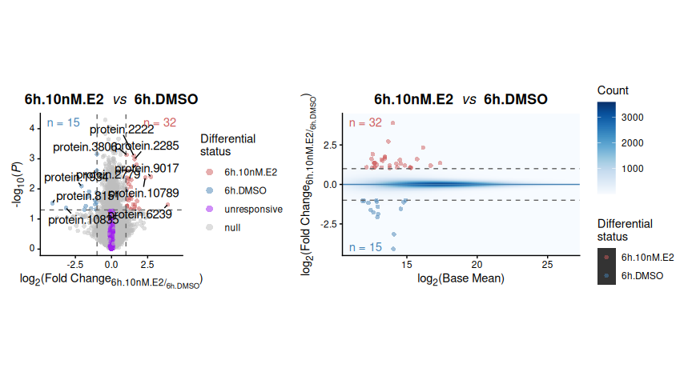

```r
volcano <- plot.volcano(dpo_analyses,
                        contrast = 1,
                        label.top.n = 10,
                        label.font.size = 4,
                        use.uncorrected.pvalue = TRUE)

MAplot <- plot.MA(dpo_analyses,
                  contrast = 1,
                  use.uncorrected.pvalue = TRUE)

patchwork::wrap_plots(volcano, MAplot)
```

#### 6.4.3.3 Correlation between contrasts

Using the function `contrast.scatter` it is possible to visualize the log<sub>2</sub>(Fold Change) correlation between two contrasts of a differential expression analyses object.

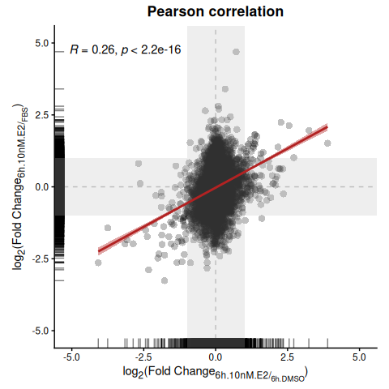

```r
contrast.scatter <-
  contrast.scatter(DEprot.analyses.object = dpo_analyses,
                   contrast.x = 1,
                   contrast.y = 2,
                   regression.line.color = "firebrick",
                   correlation.method = "pearson",
                   add.foldchange.threshold = TRUE,
                   symmetric.axes = TRUE)

contrast.scatter
```

#### 6.4.3.4 Scatter between average-LFQ values for one contrast

Using the function `contrast.LFQ` it is possible to plot a scatter of the average LFQ values for the two conditions involved in a specific contrast. Dots will be colored by log<sub>2</sub>(Fold Change), while the size corresponds to the adjusted P-value (or FDR if `prolfqua` is used).

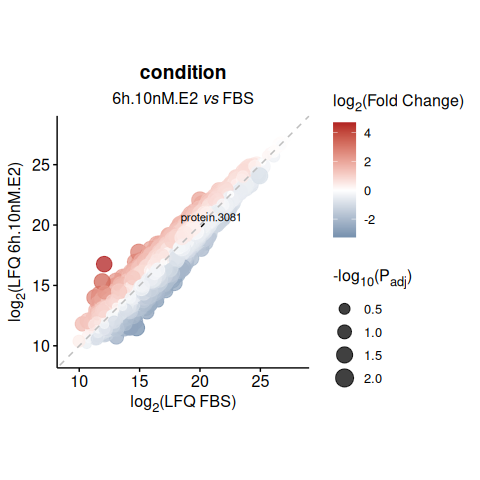

```r
contrast_LFQ <-
  contrast.LFQ(DEprot.analyses.object = dpo_analyses,
               contrast = 2,
               dot.labels = "protein.3081")

contrast_LFQ
```

#### 6.4.3.5 Heatmaps

To plot results heatmaps there are three functions available:

- `heatmap.counts`: allows for the plotting of raw, normalized or imputed counts.
- `heatmap.counts.anno`: same as `heatmap.counts`, but drawn with `ComplexHeatmap` and with annotations for samples and proteins.
- `heatmap.contrasts`: allows for the plotting of log<sub>2</sub>(FoldChange) values.

##### 6.4.3.5.1 Counts

With the `heatmap.counts` function it is possible to generate a heatmap for the raw/normalized/imputed counts. It is possible to select only specific proteins and/or subset samples (from the `column.id` column in the metadata table). If the object provided is a `DEprot.analyses` object, it is also possible to indicate to plot only differential proteins (or top.n differential proteins) from a specific contrast.  
The protein ranking definition is based on the differential score, computed as: `abs(log2(fold change)) * -log10(Padj)`.

The resulting object is of class `DEprot.counts.heatmap`, and contains the ggplot-heatmap, the row cluster and the column cluster.

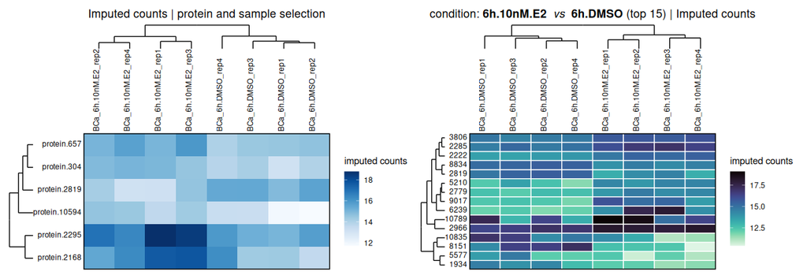

```r
## Plotting from a DEprot object
imputed_counts_heatmap <-
  heatmap.counts(DEprot.object = dpo,
                 which.data = "imputed",
                 sample.subset = dpo@metadata$column.id[grep("6h", dpo@metadata$column.id)],
                 show.protein.names = TRUE,
                 protein.subset = c("protein.2295", "protein.304", "protein.657",
                                    "protein.2819", "protein.2168", "protein.10594"),
                 title = "Imputed counts | protein and sample selection")



## Plotting from a DEprot.analyses object
## top 15 differential proteins from contrast 1
imputed_counts_heatmap_diffProteins <-
  heatmap.counts(DEprot.object = dpo_analyses,
                 which.data = "imputed",
                 contrast = 1,
                 top.n = 15,
                 palette = viridis::mako(n = 100, direction = -1),
                 cell.border.color = "white",
                 show.protein.names = TRUE,
                 sample.subset = dpo@metadata$column.id[grep("6h", dpo@metadata$column.id)],
                 use.uncorrected.pvalue = TRUE,
                 protein.names.pattern = "protein[.]",
                 title = "condition: **6h.10nM.E2** *vs* **6h.DMSO** (top 15) | Imputed counts")


## Combine heatmaps
patchwork::wrap_plots(imputed_counts_heatmap@heatmap,
                      imputed_counts_heatmap_diffProteins@heatmap)
```

Instead of “pure” counts, it is possible to compute Z-scores of the values and plot a divergent heatmap.  
In this case instead of a palette, it will be required to indicate the color for the positive, negative and 0 values.

We will apply this to the `imputed_counts_heatmap_diffProteins` heatmap from the previous example.

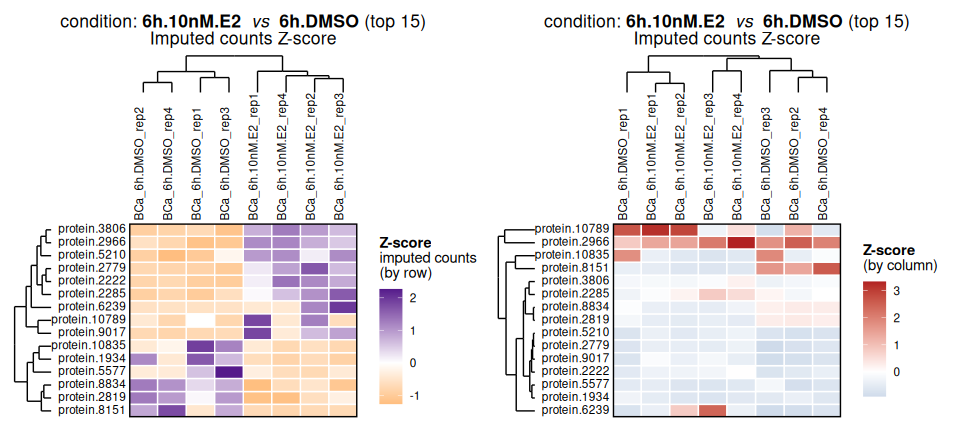

```r
## Z-score by row
imputed_counts_heatmap_diffProteins_rowScaled <-
  heatmap.counts(DEprot.object = dpo_analyses,
                 which.data = "imputed",
                 contrast = 1,
                 top.n = 15,
                 high.color = "purple4",
                 low.color = "darkorange",
                 mid.color = "white",
                 cell.border.color = "white",
                 show.protein.names = TRUE,
                 sample.subset = dpo@metadata$column.id[grep("6h", dpo@metadata$column.id)],
                 use.uncorrected.pvalue = TRUE,
                 scale = "rows",
                 title = "condition: **6h.10nM.E2** *vs* **6h.DMSO** (top 15)<br>Imputed counts Z-score")


## Z-score by column
imputed_counts_heatmap_diffProteins_columnScaled <-
  heatmap.counts(DEprot.object = dpo_analyses,
                 which.data = "imputed",
                 contrast = 1,
                 top.n = 15,
                 high.color = "firebrick",
                 low.color = "steelblue",
                 mid.color = "white",
                 cell.border.color = "white",
                 show.protein.names = TRUE,
                 sample.subset = dpo@metadata$column.id[grep("6h", dpo@metadata$column.id)],
                 use.uncorrected.pvalue = TRUE,
                 scale = "columns",
                 title = "condition: **6h.10nM.E2** *vs* **6h.DMSO** (top 15)<br>Imputed counts Z-score")


## Combine heatmaps
patchwork::wrap_plots(imputed_counts_heatmap_diffProteins_rowScaled@heatmap,
                      imputed_counts_heatmap_diffProteins_columnScaled@heatmap)
```

Ultimately, with this function it is also possible to group data based on the values of a metadata column. In this way it is possible to average the values by the values of the defined column (e.g., the replicates of a condition).

In the next example we will average the replicates of each condition using the `combined.id` column from the metadata of the `dpo_analyses` object.

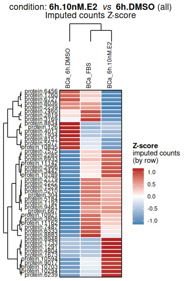

```r
imputed_counts_heatmap_diffProteins_rowScaled_grouped.by.condition <-
  heatmap.counts(DEprot.object = dpo_analyses,
                 group.by.metadata.column = "combined.id",
                 which.data = "imputed",
                 contrast = 1,
                 high.color = "firebrick",
                 low.color = "steelblue",
                 mid.color = "white",
                 cell.border.color = "white",
                 show.protein.names = TRUE,
                 use.uncorrected.pvalue = TRUE,
                 scale = "rows",
                 title = "condition: **6h.10nM.E2** *vs* **6h.DMSO** (all)<br>Imputed counts Z-score")

imputed_counts_heatmap_diffProteins_rowScaled_grouped.by.condition@heatmap
```

##### 6.4.3.5.2 Annotated counts

The function `heatmap.counts.anno` builds the same heatmap of `heatmap.counts`, and shares with it all the parameters controlling the data selection (`which.data`, `contrast`, `top.n`, `sample.subset`, `protein.subset`, `group.by.metadata.column`, `scale`). The difference is that the plot is drawn with `ComplexHeatmap` instead of `ggplot2`: the columns (samples) can be annotated with any column of the metadata table, the rows (proteins) with any column of the *protein.info* table, and the heatmap can be split in blocks.  
The object returned is of class `DEprot.counts.heatmap`, as for `heatmap.counts`, but the `heatmap` slot contains a `Heatmap` object instead of a ggplot. Row and column clusters are the usual `hclust` objects, always computed on the full matrix.

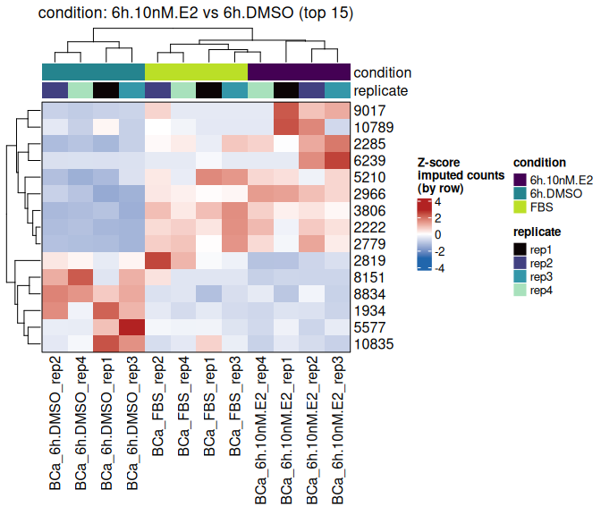

```r
counts_heatmap_annotated <-
  heatmap.counts.anno(DEprot.object = dpo_analyses,
                      which.data = "imputed",
                      contrast = 1,
                      top.n = 15,
                      scale = "row",
                      use.uncorrected.pvalue = TRUE,
                      column.annotation = c("condition", "replicate"),
                      show.protein.names = TRUE,
                      protein.names.pattern = "protein[.]",
                      title = "condition: 6h.10nM.E2 vs 6h.DMSO (top 15)")

counts_heatmap_annotated
```

The colors of the annotations are defined through `annotation.colors`, using the same syntax of `pheatmap`: a named list with one element per annotation column, each of them a vector of colors named after the values of that column. The columns that are not listed get an automatic palette, hence only the annotations that matter have to be defined.  
With `column.split` the samples are divided in blocks: either the name of a metadata column, or a number of blocks in which the column dendrogram should be cut (equivalent of `cutree`). The same applies to the proteins with `row.split`.

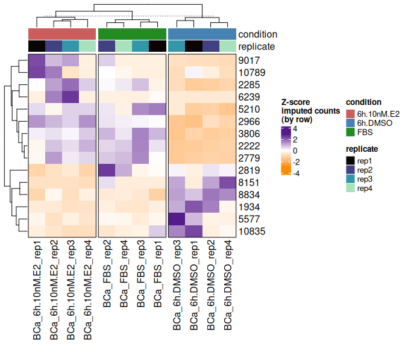

```r
counts_heatmap_annotated_split <-
  heatmap.counts.anno(DEprot.object = dpo_analyses,
                      which.data = "imputed",
                      contrast = 1,
                      top.n = 15,
                      scale = "row",
                      use.uncorrected.pvalue = TRUE,
                      column.annotation = c("condition", "replicate"),
                      column.split = "condition",
                      annotation.colors = list(condition = c("6h.10nM.E2" = "indianred",
                                                             "6h.DMSO" = "steelblue",
                                                             "FBS" = "forestgreen")),
                      high.color = "purple4",
                      low.color = "darkorange",
                      mid.color = "white",
                      show.protein.names = TRUE,
                      protein.names.pattern = "protein[.]")

counts_heatmap_annotated_split
```

The proteins are annotated in the same way, using the columns of the table stored in the *protein.info* slot (see protein annotation). Any table can be attached to an object with `add.protein.info`: in the next example the differential status and the fold change of the first contrast are used as row annotation, and the proteins are split by their differential status.

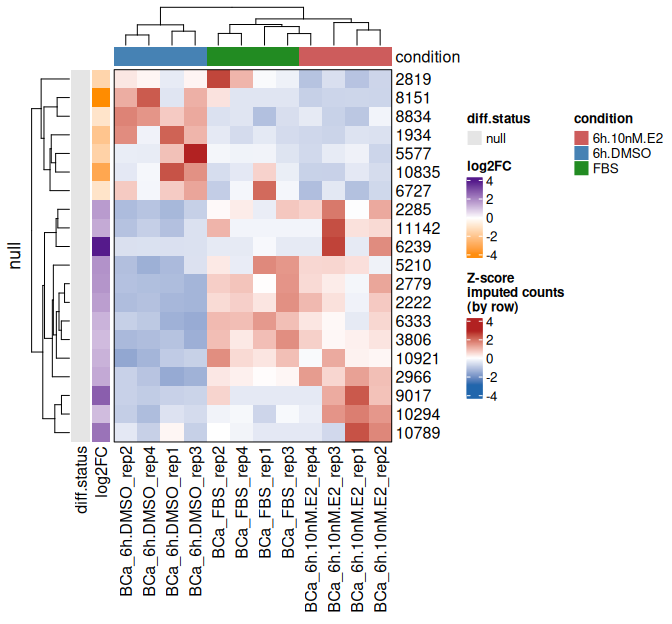

```r
## Protein annotation built on the results of the first contrast
results_contrast.1 <- get.results(DEprot.analyses.object = dpo_analyses, contrast = 1)

protein.annotation_contrast.1 <-
  data.frame(diff.status = results_contrast.1$diff.status,
             log2FC = results_contrast.1[,grep("^log2.Fold", colnames(results_contrast.1))],
             row.names = results_contrast.1$prot.id)

dpo_analyses_annotated <-
  add.protein.info(DEprot.object = dpo_analyses,
                   protein.info = protein.annotation_contrast.1,
                   overwrite = TRUE)


counts_heatmap_annotated_rows <-
  heatmap.counts.anno(DEprot.object = dpo_analyses_annotated,
                      which.data = "imputed",
                      contrast = 1,
                      top.n = 20,
                      scale = "row",
                      use.uncorrected.pvalue = TRUE,
                      column.annotation = "condition",
                      row.annotation = c("diff.status", "log2FC"),
                      row.split = "diff.status",
                      annotation.colors = list(condition = c("6h.10nM.E2" = "indianred",
                                                             "6h.DMSO" = "steelblue",
                                                             "FBS" = "forestgreen"),
                                               diff.status = c("6h.10nM.E2" = "indianred",
                                                               "6h.DMSO" = "steelblue",
                                                               "unresponsive" = "gray70",
                                                               "null" = "gray90"),
                                               log2FC = c("darkorange", "white", "purple4")),
                      show.protein.names = TRUE,
                      protein.names.pattern = "protein[.]")

counts_heatmap_annotated_rows
```

Numeric annotations, such as the `log2FC` of the example above, are displayed as a continuous scale: the vector of colors provided is spread between the minimum and the maximum of the values. To center the scale on a specific value, a color function can be passed instead of the vector of colors:

```r
annotation.colors <-
  list(log2FC = circlize::colorRamp2(breaks = c(-2, 0, 2),
                                     colors = c("darkorange", "white", "purple4")))
```

As for `heatmap.counts`, the counts can be averaged by the values of a metadata column. In this case each column of the heatmap is a group and not a sample anymore, hence only the annotations taking a single value in each group can be displayed: in the next example `condition` and `cell` are constant within each `combined.id`, while asking for `replicate` would drop it with a warning.

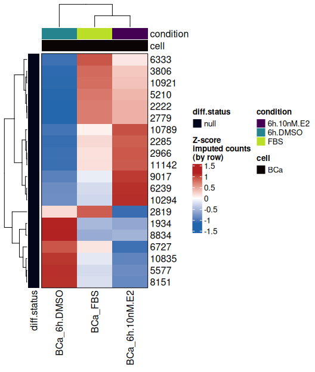

```r
counts_heatmap_annotated_grouped <-
  heatmap.counts.anno(DEprot.object = dpo_analyses_annotated,
                      group.by.metadata.column = "combined.id",
                      which.data = "imputed",
                      contrast = 1,
                      top.n = 20,
                      scale = "row",
                      use.uncorrected.pvalue = TRUE,
                      column.annotation = c("condition", "cell"),
                      row.annotation = "diff.status",
                      show.protein.names = TRUE,
                      protein.names.pattern = "protein[.]")

counts_heatmap_annotated_grouped
```

Since the `heatmap` slot contains a `Heatmap` object, everything that `ComplexHeatmap` offers can be applied on top of it: the drawing parameters, the concatenation of multiple heatmaps (`+` for the columns, `%v%` for the rows), or the addition of further annotations.

```r
## Legends on the left, all of them merged in a single block
ComplexHeatmap::draw(counts_heatmap_annotated_rows@heatmap,
                     heatmap_legend_side = "left",
                     merge_legend = TRUE)

## Two heatmaps sharing the rows, one next to the other
ComplexHeatmap::draw(counts_heatmap_annotated_rows@heatmap + counts_heatmap_annotated_grouped@heatmap)
```

These objects are drawn by `grid`, hence they cannot be combined with ggplots by `patchwork` directly. To mix the two, the heatmap has to be captured first:

```r
heatmap_grob <- grid::grid.grabExpr(ComplexHeatmap::draw(counts_heatmap_annotated@heatmap))

patchwork::wrap_plots(heatmap_grob, imputed_counts_heatmap@heatmap)
```

##### 6.4.3.5.3 Fold changes

Instead of counts, it is possible to plot the fold changes of one or multiple contrasts using the function `heatmap.contrasts`. Only differential proteins are shown.  
Also in this case it is possible to show only the top *N* differential proteins. However the top *N* of each contrast will be shown. This means that more than *N* proteins might be displayed.

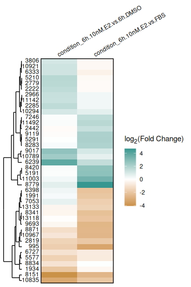

```r
FC_heatmap <-
  heatmap.contrasts(DEprot.analyses.object = dpo_analyses,
                    contrasts = c(1:2),
                    top.n = 20,
                    high.color = "#35978F",
                    low.color = "#BF812D",
                    mid.color = "white",
                    show.protein.names = TRUE,
                    use.uncorrected.pvalue = TRUE,
                    protein.names.pattern = "protein[.]")

FC_heatmap@heatmap
```

#### 6.4.3.6 Upset-plot

To identify which differential proteins are common among multiple comparisons, it is possible to generate an upset plot using the function `plot.upset`. With this function all the intersections between all the contrasts included in the provided object can be visualized by co-occurrence. It is also possible to subset only specific contrasts indicating a numeric vector in the flag `contrast.subset`.

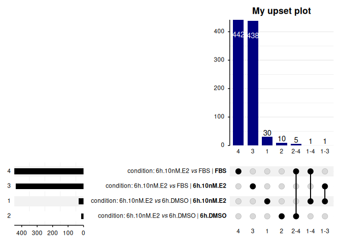

```r
upset.plot <- plot.upset(DEprot.analyses.object = dpo_analyses,
                         contrast.subset = c(1,2),
                         title = "**My upset plot**",
                         sort.intersections = "cardinality",
                         sort.sets = "descending",
                         intersection.bar.color = "navy",
                         setsize.bar.color = "black",
                         show.counts = T,
                         height.ratio = 0.5,
                         width.ratio = 0.4,
                         use.uncorrected.pvalue = TRUE)

upset.plot  # or upset.plot@upset
```

Besides the plot, also a `TRUE`/`FALSE` table is returned. The latter shows for each condition if a protein has been found to be differential. Only proteins that are differential in at least one condition are shown.

```r
upset.plot@obs.matrix
```

**Upset observations matrix**

| prot.id | condition: 6h.10nM.E2 *vs* 6h.DMSO \| **6h.10nM.E2** | condition: 6h.10nM.E2 *vs* 6h.DMSO \| **6h.DMSO** | condition: 6h.10nM.E2 *vs* FBS \| **6h.10nM.E2** | condition: 6h.10nM.E2 *vs* FBS \| **FBS** |
| --- | --- | --- | --- | --- |
| protein.17 | FALSE | FALSE | FALSE | TRUE |
| protein.25 | FALSE | FALSE | TRUE | FALSE |
| protein.44 | FALSE | FALSE | TRUE | FALSE |
| protein.48 | FALSE | FALSE | FALSE | TRUE |
| protein.53 | FALSE | FALSE | TRUE | FALSE |

### 6.4.4 Exporting results

The full object can be automatically exported - including tables, PCA, correlations, volcano and MA-plots, etc. - using the built-in function `export.analyses`:

```r
export.analyses(DEprot.analyses.object = dpo_analyses, output.folder = "./export")
```

It is also possible to generate a quality control report in html format automatically from a `DEprot`/`DEprot.analyses` object:

```r
export.report(DEprot.object = dpo_analyses,
              output.file = "QC_report.html",
              report.title = "QC Report",
              author.name = "Your Name",
              protein.summary.group.column = "combined.id",
              PCA.color.column = "combined.id",
              PCA.shape.column = "replicate")
```

# 7 **SAINT score (Significance Analysis of INTeractome)**

SAINT, developed by [Breitkreutz *et al.* (Science, 2010)](https://doi.org/10.1126/science.1176495), is a method that assigns the number of identified peptides for each interactor to a probability distribution, which is then exploited to estimate the likelihood of a true interaction (typically SAINT score ≥0.95).  
The original method uses the spectral data, however [Teo *et al.* (Proteomics, 2016)](https://doi.org/10.1002/pmic.201500499) developed a method for the computation of the SAINT scores on LFQ data named `SAINTq`. The latter is developed in C++ language; here we implemented the original algorithm in the function `SAINTq`.

> DISCLAIMER: This is an independent re-implementation of the published model, not a re-wrapping of the C++ program. It returns scores with the same definitions and behavior, but exact numbers can differ from the official `SAINTq` binary because of low-level differences (parameter estimation, missing-value and control-compression heuristics).

We benchmarked our re-implementation against the original `SAINTq` using a subset of the data from [Eickhoff *et al.* (Commun Biol, 2025)](https://doi.org/10.1038/s42003-025-08449-2) that have been reanalyzed in [Eickhoff *et al.* (NAR Genom Bioinform, 2026)](https://doi.org/10.1093/nargab/lqag015).

To compute the SAINT scores we need to indicate the control (e.g., IgG, isotype, mock-IP) ID from one of the columns of the metadata and the bait (the immunoprecipitation target; i.e. AR). Of note, multiple baits can be provided, and if the `bait` argument is left blank (`NULL`), all the non-control groups are tested against the same control.  
The result is an object of class `DEprot.SAINTq` containing 3 slots:

Slot

Description

`scores`

A named list (one element per bait) of data frames holding the SAINTq scoring tables. Each table reports one row per bait–prey pair, with the following columns:

- `Bait`: name of the bait group (a value of the `metadata.column`) scored in this table; constant within each per-bait element of the list.
- `Control`: name of the control group (a value of the `metadata.column`).
- `Prey`: identifier of the prey protein (the row name of the LFQ count matrix).
- `n.rep`: number of bait replicates in which the prey was quantified (i.e. non-missing values).
- `AvgP`: *average probability*, the main SAINTq score. It is the posterior probability of a true (bait-specific) interaction averaged across the bait replicates. It ranges in $[0,1]$; higher values indicate higher confidence.
- `MaxP`: the maximum per-replicate posterior probability across the bait replicates (the score of the single best replicate).
- `log2.FoldChange_bait.vs.control`: enrichment of the prey in the bait over the control, on the log2 scale, computed as `log2(avg.bait) - log2(avg.ctrl)`.
- `avg.bait`: mean `log2` intensity of the prey across the bait replicates.
- `avg.ctrl`: mean `log2` intensity of the prey across the control run (the background mean $\mu_F$ of the model; replaced by the global `background` value for preys never detected in the control).
- `bFDR`: Bayesian false discovery rate of the interaction, derived from the `AvgP` values as the cumulative mean of `(1 - AvgP)` down the probability-ranked list. Lower values indicate higher confidence.

`volcanoes`

A named list (one element per bait) of `ggplot` objects. Each is a volcano-style plot of the interactions for that bait, showing `log2(FoldChange)` on the x-axis against `-log10(bFDR)` on the y-axis, with the size and color of the points encoding the `AvgP` score.

`parameters`

A list recording the settings and fitted quantities used for the scoring:

- `prior.pi`: prior probability of a true interaction ($\pi_T$); either estimated by expectation-maximization or fixed by the user.
- `fold`: fold change separating the true component from the background, such that `mu_T = mu_F + log2(fold)`.
- `delta.log2`: `log2(fold)`, i.e. the additive shift (in `log2` units) applied to the background mean to define the mean of the true component.
- `sd.scale`: scaling factor of the true-component standard deviation relative to the background one (`sigma_T = sd.scale * sigma_F`).
- `min.sd`: lower bound applied to the per-prey background standard deviation, preventing over-confident scores from preys with near-constant control intensities.
- `sigma.global`: global background standard deviation (median of the per-prey control standard deviations), used as a fallback for preys with too few control measurements.
- `background`: `log2` background intensity assigned to preys never detected in any control run.
- `which.data`: the DEprot count matrix that was scored, one of `"imputed"`, `"randomized"`, `"normalized"` or `"raw"`.
- `control`: name of the control group used as the background.
- `baits`: name(s) of the bait group(s) that were scored.
- `best.n.rep`: number of top-scoring bait replicates used when averaging the per- replicate posterior probabilities into `AvgP` (the “best R replicates” option of SAINTexpress). `NULL` means that all replicates of each bait were used.

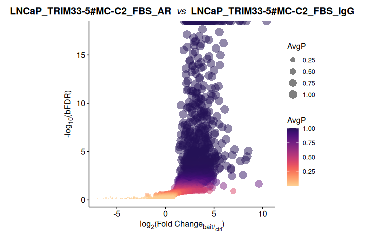

```r
saint_deprot <-
  SAINTq(DEprot.object = DEprot::rime.dpo,
         metadata.column = "group",
         control = "LNCaP_TRIM33-5#MC-C2_FBS_IgG",
         bait = "LNCaP_TRIM33-5#MC-C2_FBS_AR",
         which.data = "imputed", # use 'raw' to be closer to the original SAINTq
         fold = 5)
saint_deprot
```

```r
head(summary(saint_deprot))
```

**SAINTq results**

| Bait | Control | Prey | n.rep | AvgP | MaxP | log2.FoldChange_bait.vs.control | avg.bait | avg.ctrl | bFDR |
| --- | --- | --- | --- | --- | --- | --- | --- | --- | --- |
| LNCaP_TRIM33-5#MC-C2_FBS_AR | LNCaP_TRIM33-5#MC-C2_FBS_IgG | ZNF316 | 4 | 1 | 1 | 3.269246 | 25.45752 | 22.18827 | 0 |
| LNCaP_TRIM33-5#MC-C2_FBS_AR | LNCaP_TRIM33-5#MC-C2_FBS_IgG | AKR7A2 | 4 | 1 | 1 | 2.256096 | 25.15814 | 22.90205 | 0 |
| LNCaP_TRIM33-5#MC-C2_FBS_AR | LNCaP_TRIM33-5#MC-C2_FBS_IgG | UBR5 | 4 | 1 | 1 | 3.221221 | 25.92005 | 22.69882 | 0 |
| LNCaP_TRIM33-5#MC-C2_FBS_AR | LNCaP_TRIM33-5#MC-C2_FBS_IgG | ASS1 | 4 | 1 | 1 | 3.509069 | 26.14952 | 22.64045 | 0 |
| LNCaP_TRIM33-5#MC-C2_FBS_AR | LNCaP_TRIM33-5#MC-C2_FBS_IgG | ESRRA | 4 | 1 | 1 | 3.023876 | 25.87275 | 22.84887 | 0 |

## 7.1 Benchmark against the original `SAINTq` tool

We analyzed the same data using the original `SAINTq` (results stored in DEprot as `rime.saintq`) and compared the scores obtained between the two methods.

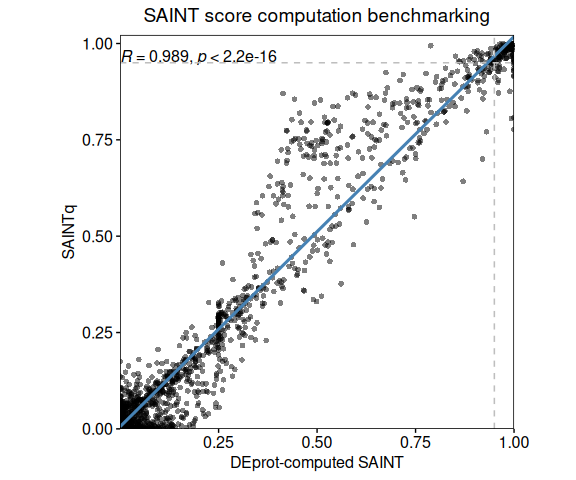

```r
sq_combo = dplyr::left_join(x = saint_deprot@scores$`LNCaP_TRIM33-5#MC-C2_FBS_AR`,
                            y = DEprot::rime.saintq, # original tool
                            by = "Prey")

ggpubr::ggscatter(data = sq_combo,
                  x = "AvgP.x",
                  y = "AvgP.y",
                  alpha = 0.5,
                  stroke = NA,
                  xlab = "DEprot-computed SAINT",
                  ylab = "SAINTq",
                  title = "SAINT score computation benchmarking") +
  geom_smooth(formula = y ~ x, method = "lm", color = "steelblue", fill = "steelblue") +
  ggpubr::stat_cor(method = "pearson", r.digits = 3) +
  geom_vline(xintercept = 0.95, color = 'gray', linetype = 2) +
  geom_hline(yintercept = 0.95, color = 'gray', linetype = 2) +
  scale_x_continuous(expand = c(0,0)) +
  scale_y_continuous(expand = c(0,0)) +
  theme(aspect.ratio = 1,
        axis.line = element_blank(),
        plot.title = ggtext::element_markdown(hjust = 0.5),
        panel.border = element_rect(fill = NA, colour = "black"))
```

# 8 **Power and sample size**

A recurrent question in a proteomics project, often asked once the experiment has already been run, is how many replicates are needed. The textbook answer, `power.t.test`, is written for a single comparison and returns a number that is far too small here: a differential analysis consists of ten thousand tests, and the threshold that a protein has to cross is not 0.05, but whatever the multiple-testing correction leaves once the whole table has been adjusted. The two elements are linked: the more responsive proteins there are, the more the correction can afford to relax, and the easier it becomes for each of them to be detected. An estimate that ignores this link is not conservative, it is simply wrong in an unknown direction.

[Jung (Bioinformatics, 2005)](https://doi.org/10.1093/bioinformatics/bti456) turned the link into an equation. If `m1` proteins truly respond and the average power over them is 1-β, the expected number of true discoveries is `m1(1-`β`)` and the expected number of false ones is `m0`α, so controlling the FDR at a level *f* means:

*α = f · m<sub>1</sub> · (1-β) / [(1 - f) · m<sub>0</sub>]*

α depends on the power, the power depends on α, and the couple that satisfies both is found by root finding at each sample size. [Liu & Hwang (Bioinformatics, 2007)](https://doi.org/10.1093/bioinformatics/btl664) showed that the relation reduces to a closed form when a single effect size is assumed. The function `estimate.power` implements both approaches: the responsive proteins can either keep the effect sizes they actually showed, or be collapsed onto one target fold change.

No external power package has to be installed. Indeed, the results table of any of the four differential functions already stores the log2-FoldChanges and the per-group standard deviations, which are the only quantities read by the calculation.

## 8.1 Basic usage

The only mandatory input is a `DEprot.analyses` object and the index of the contrast to use for the estimation:

```r
power.estimation <- estimate.power(DEprot.analyses.object = dpo_analyses,
                                   contrast = 1,
                                   sample.size.range = c(2, 30),
                                   target.power = 0.8)

power.estimation
>         Contrast | 6h.10nM.E2.vs.6h.DMSO (paired)
>      Counts used | imputed (t.test)
>  Proteins tested | 12944 (m1 = 1674, pi0 = 0.871)
>      Effect size | empirical, median |d| = 1.22
>              FDR | 0.05
>  Current n/group | 4
> Required n/group | 13 (average power 0.8)
```

The `show` method prints the assumptions and the answer, while the three plots are obtained separately. The `...` are passed to `patchwork::wrap_plots`, so the layout can be arranged as needed:

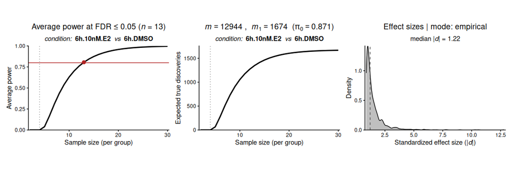

```r
plot(power.estimation, nrow = 1)
```

- The first panel shows the average power as a function of the number of replicates per group, with the target as a horizontal line and the size of the current experiment as a vertical dotted one.
- The second one displays the expected number of true discoveries. This is usually the quantity of interest, since it saturates at `m1` and quantifies how much is gained by adding replicates.
- The third one shows the distribution of the standardized effect sizes on which the whole calculation rests. We suggest to inspect this panel before trusting the other two.

The numbers behind the curves are in the `power.table` slot:

```r
head(power.estimation@power.table)
```

**Power table results**

| n.per.group | alpha | average.power | expected.TP | expected.FP | expected.discoveries | expected.FDR |
| --- | --- | --- | --- | --- | --- | --- |
| 2 | 0.0000000 | 0.0000000 | 0.0000167 | 0.0000009 | 0.0000176 | 0.05 |
| 3 | 0.0000000 | 0.0000000 | 0.0000167 | 0.0000009 | 0.0000176 | 0.05 |
| 4 | 0.0000000 | 0.0000000 | 0.0000167 | 0.0000009 | 0.0000176 | 0.05 |
| 5 | 0.0003057 | 0.0390982 | 65.4504412 | 3.4447601 | 68.8952012 | 0.05 |
| 6 | 0.0013049 | 0.1669139 | 279.4138026 | 14.7059896 | 294.1197922 | 0.05 |
| 7 | 0.0024126 | 0.3086052 | 516.6050322 | 27.1897385 | 543.7947708 | 0.05 |

| Column | Description |
| --- | --- |
| *n.per.group* | number of replicates per group tested |
| *alpha* | per-test significance level required to keep the FDR at the requested level |
| *average.power* | power averaged over the responsive proteins |
| *expected.TP* | expected number of true discoveries, `m1` × *average.power* |
| *expected.FP* | expected number of false discoveries, `m0` × α |
| *expected.discoveries* | total size of the list that would be reported |
| *expected.FDR* | realized FDR, equal to the level requested by construction |

## 8.2 Two ways of choosing the effect size

By default (`effect.size = "empirical"`) the proportion of null proteins π<sub>0</sub> is estimated from the p-value distribution, the `m1` proteins with the smallest p-values are taken as the responsive ones, and the power is averaged over the effect sizes they showed. This uses all the information of the pilot experiment, and it inherits its optimism: those proteins were selected *because* they came out significant, so their effect sizes represent the upper tail of a distribution and not a sample from it. This is the winner’s curse, and it becomes more severe as π<sub>0</sub> approaches 1. The `min.effect.size` parameter blunts it by discarding the small effects, without removing it.

The alternative is to state the effect worth detecting instead of measuring it. `desired.FC` takes a fold change on the linear scale and divides `log2(desired.FC)` by a quantile of the observed pooled standard deviations. The question then becomes *“how many replicates do I need to see a 1.5-fold change on a protein of typical variability”*:

```r
power.FC1.5 <- estimate.power(DEprot.analyses.object = dpo_analyses,
                              contrast = 1,
                              desired.FC = 1.5,
                              sd.quantile = 0.75,
                              target.power = 0.8)

power.FC1.5
>         Contrast | 6h.10nM.E2.vs.6h.DMSO (paired)
>      Counts used | imputed (t.test)
>  Proteins tested | 12944 (m1 = 1674, pi0 = 0.871)
>      Effect size | desired.FC = 1.5 (sd quantile: 0.75), median |d| = 1.367
>              FDR | 0.05
>  Current n/group | 4
> Required n/group | 11 (average power 0.8)
```

Setting `sd.quantile = 0.75` plans for a protein noisier than three quarters of the proteome, a conservative choice when the estimate has to be defended in a grant application. The median is the default and describes the typical protein.

> A single numeric value passed to `effect.size` does the same thing directly, on the standardized scale: `effect.size = 1` means one pooled standard deviation, regardless of what the fold change corresponds to.

## 8.3 What inflates the estimate

The estimate can be optimistic for three reasons, and only the first one raises a warning.

The first one is imputation. Every value drawn from the bottom of the distribution to fill a blank is similar to the other values drawn in the same way, so the within-group variance shrinks, the standardized effect sizes grow, and the required sample size falls. The function checks `counts.used` and raises a warning when the differential analyses were run on imputed or randomized counts, but the warning cannot correct the numbers. The honest input is a differential analysis run on the normalized counts and restricted to the proteins quantified in all the samples of the contrast:

```r
complete.proteins <- rownames(dpo_norm@norm.counts)[rowSums(is.na(dpo_norm@norm.counts)) == 0]

dpo_complete <- filter.proteins(DEprot.object = dpo_norm,
                                proteins = complete.proteins,
                                mode = "keep")

dpo_complete <- diff.analyses.limma(DEprot.object = dpo_complete,
                                    contrast.list = list(c("condition", "6h.10nM.E2", "6h.DMSO")),
                                    which.data = "normalized")

estimate.power(dpo_complete, contrast = 1)
```

The second one is the selection of the responsive set, discussed in the previous paragraph.

The third one concerns `diff.analyses.proDA`, and is worth stating explicitly since this function is otherwise the one handling the missing values most honestly. `estimate.power` reads the per-protein standard deviations, and these are computed on the observed values only. For a protein affected by dropout, the observed values correspond to the upper part of its intensity distribution, so the standard deviation is estimated on a truncated sample and comes out too small. The number of replicates in which the protein was actually quantified is taken from the `n.detected.<group>` columns, hence the group sizes are correct, while the dispersion is not. On a proDA object the full-table estimate should be read as an optimistic bound, and the complete-cases version above as the realistic one.

> Objects generated with `stat.test = "wilcoxon"` are accepted, since the standard deviations are stored regardless of the test. The calculation nonetheless describes the power of a *t*-test in the planned experiment; for normally distributed data a rank test needs roughly 5% more samples to reach the same power, so also in this case the estimate is mildly optimistic.

> Relation with `MSstats::designSampleSize`: `MSstats` answers the same question with the same logic, converting the FDR into a per-test α under an assumed ratio between null and responsive features and then solving the two-sample non-central *t* equation. The difference is that it collapses the problem onto one `desiredFC` and one standard deviation taken from the fitted model, corresponding to the `desired.FC` mode described above.

## 8.4 Extrapolating with `power4peaks`

`estimate.power` is deliberately parametric: it assumes the effect sizes observed in the pilot and asks what a larger experiment would do with them.  
A complementary approach consists in reconstructing the whole density of the effect sizes from the distribution of the test statistics. This is the strategy of [`power4peaks`](https://sebastian-gregoricchio.github.io/power4peaks/), based on the deconvolution of [Ferreira & Zwinderman (The Int. J. of Biostat., 2006)](https://doi.org/10.2202/1557-4679.1018). Any `DEprot.analyses` object can be converted directly:

```r
p4p.stats <- power4peaks::as.power4peaks(object = dpo_analyses,
                                         contrast = 1)

p4p.power <- power4peaks::compute.power(power4peaks.stats = p4p.stats,
                                        sample.size.range = c(2, 30),
                                        power.threshold = 0.8)

p4p.power
```

The conversion covers all the differential functions of `DEprot`: the moderated and ordinary *t* statistics of `diff.analyses`, `diff.analyses.limma`, `diff.analyses.prolfqua` and `diff.analyses.proDA` are passed as such, while the rank statistics of a Wilcoxon test are converted into signed normal deviates through the p-values. For `proDA` the group sizes are rescaled to the effective sample size estimated by the dropout model (`n.approx`), since this, and not the nominal number of samples, is the amount of information on which the statistics were computed.

The two answers should be read together. A disagreement between them is in itself an informative result, and it typically occurs when π<sub>0</sub> is poorly determined; a difference of one or two replicates describes fairly well the uncertainty of the whole exercise.

> Neither method models the other half of the problem: in LFQ proteomics, adding samples increases the power per protein, but also the number of proteins that pass the missing-value filter and reach the test. Both curves therefore describe the power over the proteins quantified in the pilot experiment, and both under-estimate what a larger experiment would actually return.

# 9 **Other tools**

## 9.1 Count detected proteins

In order to know how many proteins have been detected in each sample, it is possible to use the function `protein.summary`. A stacked bar plot will be generated per each sample. The input object must belong to either `DEprot` or `DEprot.analyses` classes.

> **NOTE**: this plot is meaningful only on raw and/or unimputed normalized data. Indeed, estimation of missing values is not possible on the imputed tables.

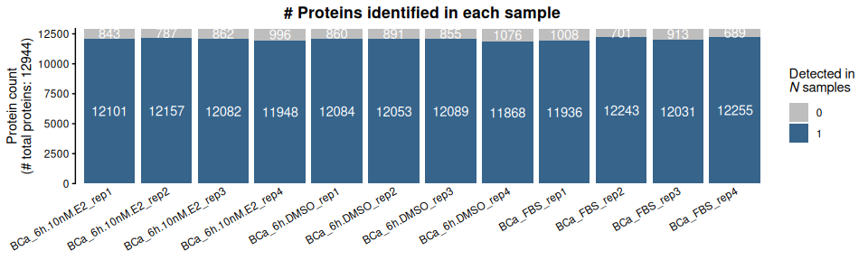

```r
protein.counts <-
  protein.summary(DEprot.object = dpo_analyses,
                  n.labels = "counts",
                  show.frequency = FALSE,
                  colors = c("gray", "steelblue4"),
                  title = "**# Proteins identified in each sample**")

protein.counts
```

Another possibility is to study the protein co-detection by sample groups. A group can be defined using any column of the metadata table. In the output stacked bar plot, each color will show how many proteins in how many samples within a group were detected.

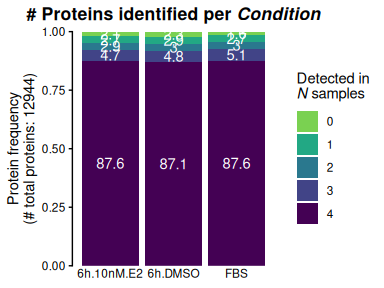

```r
protein.counts.byCondition <-
  protein.summary(DEprot.object = dpo_analyses,
                  group.column = "condition",
                  n.labels = "percentage",
                  show.frequency = TRUE,
                  x.label.angle = 0,
                  title = "**# Proteins identified per _Condition_**")

protein.counts.byCondition
```

## 9.2 Individual protein expression

Using the function `expression.boxplot` it is possible to generate boxplots of the expression of individual proteins.  
The expression can be grouped by a column of the metadata using the `group.by.metadata.column` parameter. Furthermore it is possible to scale the values using Z-scores (parameter `scale.expression = TRUE`).

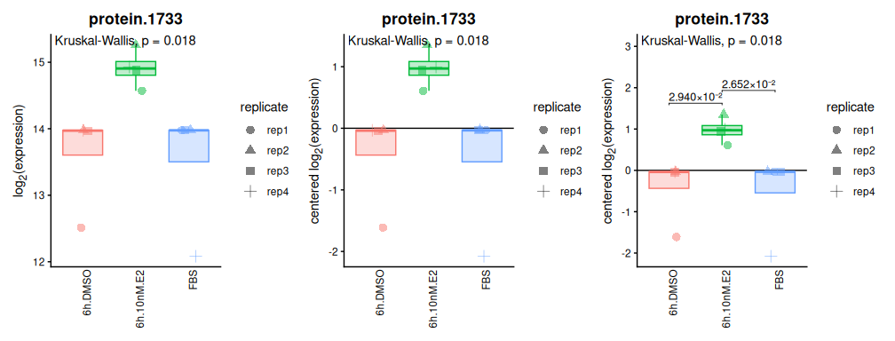

```r
### raw expression
protein.1733_raw <-
  expression.boxplot(DEprot.object = dpo,
                     protein.id = "protein.1733",
                     which.data = "imputed",
                     shape.column = "replicate",
                     group.by.metadata.column = "condition",
                     group.levels = c("6h.DMSO", "6h.10nM.E2", "FBS"),
                     scale.expression = FALSE,
                     x.label.angle = 90)


### scaled expression
protein.1733_scaled <-
  expression.boxplot(DEprot.object = dpo,
                     protein.id = "protein.1733",
                     which.data = "imputed",
                     shape.column = "replicate",
                     group.by.metadata.column = "condition",
                     group.levels = c("6h.DMSO", "6h.10nM.E2", "FBS"),
                     scale.expression = TRUE,
                     x.label.angle = 90)


### scaled expression + p-values
protein.1733_scaled_pairwise <-
  expression.boxplot(DEprot.object = dpo,
                     protein.id = "protein.1733",
                     which.data = "imputed",
                     shape.column = "replicate",
                     group.by.metadata.column = "condition",
                     group.levels = c("6h.DMSO", "6h.10nM.E2", "FBS"),
                     scale.expression = TRUE,
                     x.label.angle = 90,
                     pairwise.comparisons = TRUE,
                     pairwise.test.type = "wilcox",
                     pairwise.p.label = "p.value",
                     pairwise.p.decimals = 3,
                     pairwise.include.ns = FALSE)

patchwork::wrap_plots(protein.1733_raw,
                      protein.1733_scaled,
                      protein.1733_scaled_pairwise,
                      nrow = 1)
```

## 9.3 Filter proteins

For certain analyses it might be necessary to filter-out/keep only certain specific proteins (e.g., keep only nuclear proteins).  
With the function `filter.proteins` it is possible to indicate a vector containing the protein IDs (it must correspond to the row names of the counts table) and choose whether to `"keep"` or `"remove"` these proteins.

This function works for both `DEprot` and `DEprot.analyses` classes. The output will look exactly like the original, however counts tables (raw, normalized, imputed), count boxplots, PCAs, correlations, differential tables, differential protein counts, volcano and MA-plot will be recomputed.

> **NOTE**: we discourage the filtering before normalization/batch correction and imputation, as well as before limma-based differential analyses. All these methods are based on the assumption that the proteins ‘available’ are ‘all’ the proteins available, which is not the case.

### 9.3.1 Filtering examples

Hereafter are shown two examples for keeping nuclear proteins or removing cytoplasmic proteins.

> Notice that this is only an example and, since the protein IDs are randomized, it would not be applicable to the example dataset available with `DEprot`. Furthermore `DEprot` does not include the packages `AnnotationDbi` and `org.Hs.eg.db`, which can be installed through the `Bioconductor` portal.

**KEEP NUCLEAR PROTEINS**

```r
nucleus <- AnnotationDbi::select(org.Hs.eg.db::org.Hs.eg.db,
                                 keytype = "GOALL",
                                 keys = "GO:0005634", #nucleus
                                 columns = c("SYMBOL", "UNIPROT"))

dpo_analyses_nuclear <- filter.proteins(DEprot.object = dpo_analyses,
                                        proteins = nucleus$SYMBOL,
                                        mode = "keep")
```

**REMOVE CYTOPLASMIC PROTEINS**

```r
cytoplasm <- AnnotationDbi::select(org.Hs.eg.db::org.Hs.eg.db,
                                   keytype = "GOALL",
                                   keys = "GO:0005737", #cytoplasm
                                   columns = c("SYMBOL", "UNIPROT"))

dpo_analyses_nuclear <- filter.proteins(DEprot.object = dpo_analyses,
                                        proteins = cytoplasm$SYMBOL,
                                        mode = "remove")
```

## 9.4 Filter samples

Sometimes you need to drop a few samples (e.g., a failed run, or an outlier) after you have already normalized, randomized and imputed. Because imputation depends on the group structure, you cannot just delete columns; the whole pipeline has to be redone on what is left. The function `filter.samples` does that for you: it reads the settings off the object and replays each step on the retained samples.

It works with objects of class `DEprot` and `DEprot.analyses`. In the case of the latter, also the differential analyses are re-performed using the same parameters (if possible).

```r
dpo.clean <- filter.samples(DEprot.object = dpo.imputed,
                            samples = c("Sample_A", "Sample_B"),
                            mode = "remove",
                            verbose = TRUE)
```

## 9.5 Re-apply thresholds to `DEprot.analyses` object

In certain cases, when several contrasts are defined, the differential analysis computation can be time consuming. On the other hand, one might want to change the thresholds used to define the differential status of the proteins. To avoid the re-computation of the differentials from the beginning, the function `reapply.thresholds` can be used to re-compute the differential status, re-plot volcanoes and MA-plots, and re-compute the `n.diff` summary table.

```r
dpo_analyses_fc1.5 <-
  reapply.thresholds(dpo_analyses,
                     linear.FC = 1.5,
                     p.adjusted = 0.05,
                     linear.FC.unresp.range = c(1/1.1, 1.1),
                     up.color = "indianred",
                     down.color = "steelblue",
                     unresponsive.color = "purple",
                     null.color = "gray")

summary(dpo_analyses_fc1.5)
>                        contrast.id group.factor     group1  group2 paired.test
> 1 condition: 6h.10nM.E2 vs 6h.DMSO    condition 6h.10nM.E2 6h.DMSO        TRUE
> 2 condition: 6h.10nM.E2 vs 6h.DMSO    condition 6h.10nM.E2 6h.DMSO        TRUE
> 3 condition: 6h.10nM.E2 vs 6h.DMSO    condition 6h.10nM.E2 6h.DMSO        TRUE
> 4 condition: 6h.10nM.E2 vs 6h.DMSO    condition 6h.10nM.E2 6h.DMSO        TRUE
> 5     condition: 6h.10nM.E2 vs FBS    condition 6h.10nM.E2     FBS        TRUE
> 6     condition: 6h.10nM.E2 vs FBS    condition 6h.10nM.E2     FBS        TRUE
> 7     condition: 6h.10nM.E2 vs FBS    condition 6h.10nM.E2     FBS        TRUE
> 8     condition: 6h.10nM.E2 vs FBS    condition 6h.10nM.E2     FBS        TRUE
>    diff.status    n median.FoldChange
> 1      6h.DMSO    0                NA
> 2   6h.10nM.E2    0                NA
> 3 unresponsive 8486       0.004313803
> 4         null 4458       0.150214925
> 5          FBS  832      -0.826587688
> 6   6h.10nM.E2  732       0.922028515
> 7 unresponsive 2330      -0.012852350
> 8         null 9050      -0.181689350
```

## 9.6 GSEA and OverRepresentation Analyses (ORA)

Enrichment analyses can be performed on a full contrast of a `DEprot.analyses` object (GSEA) or on the subset of proteins that belong to a specific category of `diff.status` in the results table of the given contrast (ORA).

For these analyses a geneSet table will be required as “reference”. The latter must be a data.frame with two columns: “gs_name” (geneSet name) and “gene_symbol” (corresponding to the protein id).  
In `DEprot` we provide a ready-to-use list of protein complexes obtained from the [CORUM](https://mips.helmholtz-muenchen.de/corum/) database.

> Notice that the “gene_symbol” values must match the “prot.id” in the result tables. To this end, the `geneset.enrichment` function contains the parameter `gsub.pattern.prot.id` that will be used to remove a pattern from the “prot.id”s.

In the following example we will show how to create a geneSet table from the CORUM data and use it for GSEA and ORA analyses.

### 9.6.1 Define geneSet

```r
## GeneSet Enrichment Analyses
data("corum_v5.0", package = "DEprot")

corum_geneSet <-
  corum_v5.0 %>%
  dplyr::filter(organism == "Human") %>%
  dplyr::rename(gs_name = complex.name,
                gene_symbol = protein.members) %>%
  dplyr::select(gs_name, gene_symbol)

corum_geneSet
```

**CORUM protein complexes (v5.0)**

| gs_name | gene_symbol |
| --- | --- |
| BCL6-HDAC4 complex | BCL6 |
| BCL6-HDAC4 complex | HDAC4 |
| BCL6-HDAC5 complex | BCL6 |
| BCL6-HDAC5 complex | HDAC5 |
| BCL6-HDAC7 complex | BCL6 |
| BCL6-HDAC7 complex | HDAC7 |
| Multisubunit ACTR coactivator complex | CREBBP |
| Multisubunit ACTR coactivator complex | EP300 |
| Multisubunit ACTR coactivator complex | KAT2B |
| Multisubunit ACTR coactivator complex | NCOA3 |

### 9.6.2 Perform enrichment analyses

#### 9.6.2.1 Compare ranking methods for GSEA

For GSEA analyses the genes in the differential table of the provided contrast can be ranked either by using the log<sub>2</sub>(Fold Change) [default] or the Spearman’s correlation of the imputed counts between the two groups. Depending on the sample size, these two methods can lead to different rankings. To compare the two methods it is possible to plot the correlation of the two ranks and scores using `compare.ranking`:

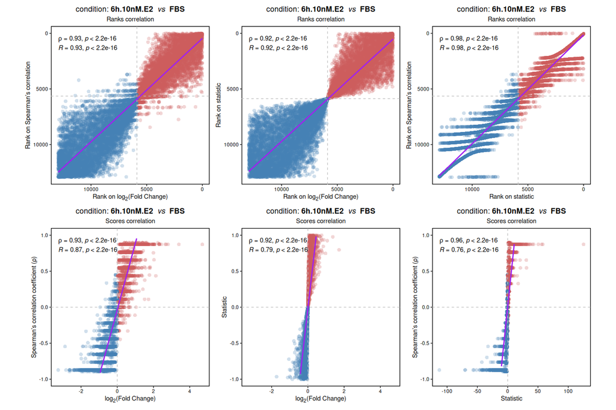

```r
compare.ranking(DEprot.analyses.object = dpo_analyses,
                contrast = 2)
```

#### 9.6.2.2 GeneSet Enrichment Analyses (GSEA)

```r
GSEA.results <-
  geneset.enrichment(DEprot.analyses.object = dpo_analyses,
                     contrast = 1,
                     TERM2GENE = corum_geneSet,
                     enrichment.type = "GSEA",
                     gsea.rank.method = "foldchange", # or correlation
                     gsub.pattern.prot.id = "_HUMAN|;.*",
                     pvalueCutoff = 0.05,
                     pAdjustMethod = "BH",
                     dotplot.n = 10)
```

Results can be visualized using `NES.plot` and `plot.GSEA`.  
Other plots can be found in the output object (slots: `protein.network`, `pathway.network`, `NES.plot`, `dotplot_gene.ratio`); have a look at the `DEprot::test.toolbox$gsea.results` dummy example.

#### 9.6.2.3 OverRepresentation Analyses (ORA)

```r
ORA.results <-
  geneset.enrichment(DEprot.analyses.object = dpo_analyses,
                     contrast = 1,
                     TERM2GENE = corum_geneSet,
                     enrichment.type = "ORA",
                     gsub.pattern.prot.id = "_HUMAN|;.*",
                     pvalueCutoff = 0.05,
                     qvalueCutoff = 0.05,
                     pAdjustMethod = "BH",
                     diff.status.category = "6h.10nM.E2",
                     dotplot.n = 10)
```

Some plots can be found in the output object (slots: `protein.network`, `pathway.network`, `dotplot_gene.ratio`, `dotplot_fold.enrichment`); have a look at the `DEprot::test.toolbox$ora.results` dummy example.

#### 9.6.2.4 Enrichment output

The output is an object of class `DEprot.enrichResult`:

| Slot | Description |
| --- | --- |
| *enrichment.discovery* | the direct output from `clusterProfiler::GSEA/enricher` (GSEA and ORA, respectively) |
| *protein.network* | a string plot showing protein networks (`clusterProfiler::cnetplot`) |
| *pathway.network* | a list with clusters and string plot showing pathway/set networks (`aPEAR::enrichmentNetwork`) |
| *NES.plot* (GSEA only) | a bar plot showing the NES scores for each significantly enriched geneSet |
| *dotplot_gene.ratio* | a dotplot showing the geneRatios for each significantly enriched geneSet |
| *dotplot_fold.enrichment* (ORA only) | a dotplot showing the foldEnrichment for each significantly enriched geneSet |
| *parameters* | a list containing the parameters used to run the analyses |
| *affinity.propagation* | if affinity propagation was applied via `simplify.enrichment`, here can be found the results |

#### 9.6.2.5 Reduce size of the enrichment by affinity propagation

The function `simplify.enrichment` applies the affinity propagation method developed by [Elizarraras *et al.*](https://doi.org/10.1093/nar/gkae456) and implemented in [WebGestalt](https://www.webgestalt.org/) online toolkit.  
This reduces the size of redundant enrichment discoveries.

```r
GSEA.results.simplified <- simplify.enrichment(GSEA.results)
ORA.results.simplified <- simplify.enrichment(ORA.results)
```

### 9.6.3 Enrichments on a sPLS-DA

The results of a sPLS-DA can be tested for geneset enrichment with `sPLSDA.enrichment`, which returns the same `DEprot.enrichResult` class produced by `geneset.enrichment`. Everything downstream therefore works unchanged: `NES.plot`, `plot.GSEA`, `simplify.enrichment`, `combine.enrichments` and `divergent.enrichment`.

```r
## Over-representation of the selected proteins
splsda.ora <- sPLSDA.enrichment(DEprot.sPLSDA.object = splsda,
                                TERM2GENE = corum_geneSet,
                                enrichment.type = "ORA",
                                component = 1,
                                direction = "both")
```

The background is the list of proteins that entered the model, which is the only sensible universe: a protein that was never quantified had no chance of being selected. This is the analysis the sparse model is built for, and the one to prefer.

```r
## GSEA on the complete ranking
splsda.gsea <- sPLSDA.enrichment(DEprot.sPLSDA.object = splsda,
                                 TERM2GENE = corum_geneSet,
                                 enrichment.type = "GSEA",
                                 component = 1,
                                 gsea.rank.method = "loading")
```

A GSEA needs a complete ranking, and the sparse loadings are not one: every protein that was not selected has a coefficient of exactly zero, which leaves a handful of ranked entries followed by thousands of ties. The running-sum statistic walks those ties in whatever order they happen to be sorted in, so the enrichment score is not even reproducible. On top of that, the sparsity penalty keeps one member of a pair of correlated proteins and drops the other, which is precisely the situation inside a pathway, so the aggregation at the set level is deflated in a way that has nothing to do with biology.

This is why `perform.sPLSDA` also fits a plain, non-sparse PLS-DA on the same data and the same number of components. It involves no resampling, so it costs nothing, and its loading vector covers every protein of the matrix: complete, free of ties, and signed towards the `reference.group`. That vector, stored in the `full.loadings` slot, is what `gsea.rank.method = "loading"` uses. The unsigned VIP scores of the same model are available with `gsea.rank.method = "vip"`, keeping in mind that only a positive NES is interpretable on an unsigned ranking.

The ranking can also be pulled out and used on its own:

```r
ranking <- get.sPLSDA.ranking(DEprot.sPLSDA.object = splsda,
                              component = 1,
                              metric = "loading")

head(ranking)
```

> On a design with more than two classes, a component separates the reference group from a mixture of the others rather than reproducing a pairwise contrast. The sign should be read as “towards the reference group”, not as a fold change, and a differential contrast remains the cleaner input for a GSEA whenever the question is really about two groups. The sPLS-DA ranking earns its place when a component captures structure that the pairwise comparisons miss.

### 9.6.4 Combine multiple enrichments

Enrichments performed separately can be displayed together: different contrasts, different `diff.status` categories, different timepoints, or a combination of these. Both functions take a named list in which each element can be a `DEprot.enrichResult` object, an `enrichResult`/`gseaResult` object coming directly from [clusterProfiler](https://bioconductor.org/packages/release/bioc/html/clusterProfiler.html), a `DEprot.timecourse.enrichment` object, or simply a result table. The three sources can be mixed in the same list.  
The names of the list are used as labels and define the order of the discoveries in the plots.

> Notice that a `DEprot.timecourse.enrichment` carries several discoveries at once: each of its clusters is expanded into an independent discovery named `<list.name>.cluster.<k>`.

#### 9.6.4.1 Merged dotplot

`combine.enrichments` displays the discoveries on the x-axis and the genesets on the y-axis. The size of the dots corresponds to the fold enrichment (or to the gene ratio), their color to the significance, and the number written inside to the count of proteins found in that geneset.

```r
combined <-
  combine.enrichments(enrichment.list = list(`E2 6h` = ORA.results.6h,
                                             `E2 24h` = ORA.results.24h,
                                             `E2 48h` = ORA.results.48h),
                      dotplot.n = 5,
                      padj.cutoff = 0.05,
                      size.by = "FoldEnrichment",
                      order.by = "discovery")

combined$dotplot
```

For each discovery only the top `dotplot.n` genesets are kept, and the plot shows the union of these selections: a geneset picked because of one contrast is then displayed for all of them, which is what makes the comparison possible. A specific set of genesets can be imposed with the `terms` parameter, in which case `dotplot.n` is ignored.

Genesets that were tested but did not pass the `padj.cutoff` in a given discovery are drawn as empty grey dots, so that a missing dot keeps the meaning of “the geneset was not returned at all by that enrichment”. Since `clusterProfiler` filters its own output, these grey dots appear only if the single enrichments were run with permissive thresholds (`pvalueCutoff = 1`, `qvalueCutoff = 1`). Use `show.non.significant = FALSE` to hide them.

The vertical order of the genesets is defined by `order.by`:

| Value | Description |
| --- | --- |
| *discovery* | sorted by the discovery in which each geneset is the most significant, generating a diagonal pattern |
| *significance* | sorted by the best adjusted p-value |
| *clustering* | hierarchical clustering of the enrichment values, placing next to each other the genesets with a similar profile |
| *alphabetical* | alphabetical order |

> Notice that the fold enrichment is not defined for a GSEA: to include GSEA discoveries in the plot use `size.by = "GeneRatio"`, otherwise they will be dropped (with a warning).

#### 9.6.4.2 Divergent bar plot

When two enrichments correspond to the two sides of the same comparison, for instance the ORA of the proteins up- and down-regulated in a contrast, `divergent.enrichment` plots them back-to-back: the first element of the list on the positive side, the second one with the sign inverted.

```r
ORA.E2 <-
  geneset.enrichment(DEprot.analyses.object = dpo_analyses,
                     contrast = 1,
                     TERM2GENE = corum_geneSet,
                     enrichment.type = "ORA",
                     gsub.pattern.prot.id = "_HUMAN|;.*",
                     diff.status.category = "6h.10nM.E2")

ORA.DMSO <-
  geneset.enrichment(DEprot.analyses.object = dpo_analyses,
                     contrast = 1,
                     TERM2GENE = corum_geneSet,
                     enrichment.type = "ORA",
                     gsub.pattern.prot.id = "_HUMAN|;.*",
                     diff.status.category = "6h.DMSO")


divergent <-
  divergent.enrichment(enrichment.list = list(`6h E2` = ORA.E2,
                                              `6h DMSO` = ORA.DMSO),
                       value = "FoldEnrichment",
                       top.n = 10,
                       padj.cutoff = 0.05)

divergent$divergent.plot
```

The top `top.n` genesets are taken independently for each side, so both are represented even when one of the two is far more enriched than the other. Genesets found on both sides share a single row and their bars face each other.

The length of the bars is set by `value` and can be the `FoldEnrichment`, the `GeneRatio`, the `Count`, the `NES` or the `padj` (plotted as -log<sub>10</sub>). Only the magnitude of the metric is used, the side being given by the position in the list. The transparency of the bars is proportional to the significance and the labels at the end of each bar indicate the count of proteins over the size of the geneset, exactly as in `NES.plot`.

#### 9.6.4.3 Combined enrichment output

Both functions return a list with two elements:

| Element | Description |
| --- | --- |
| *results* | data.frame combining the results of all the discoveries |
| *dotplot* / *divergent.plot* | the ggplot object |

The `results` table is shared by the two functions: the columns of GSEA and ORA analyses are harmonized (`discovery`, `enrichment.type`, `ID`, `alias`, `Count`, `set.size`, `GeneRatio.numeric`, `FoldEnrichment`, `NES`, `pvalue`, `p.adjust`), which is what allows discoveries of different origin to be plotted on the same axes. For a GSEA the leading edge is used as the equivalent of the ORA `Count`, and the size of the geneset as its background.

## 9.7 Export Materials and Methods

It is possible to generate a material an methods paragraph for your analyses.

```r
mm <- generate.mm(dpo_analyses, verbose = TRUE)
> MATERIAL AND METHODS
>
> Protein-level label-free quantification (LFQ) intensities were processed in R (v4.6.1) (1) with the
> DEprot package (v2.1.0) (2,3). The matrix used for the analyses covers 12944 proteins across 12
> samples and the intensities are log2-transformed. Samples are annotated by the following variables:
> sample.id, cell, condition, combined.id, replicate, old.column.id. Intensities were normalized
> across samples by mean/median-balanced quantile normalization (MBQN) (4), an implementation of
> quantile normalization in which rank-invariant and nearly rank-invariant features are centred
> before the normalization, so that their profile is not flattened. Features were balanced on their
> median and the rank-invariance frequency threshold above which the balancing is applied was set to
> 0.5. Proteins undetected in all the samples of a given 'combined.id' group were treated as missing
> not at random: for those groups, values were drawn at random from the bottom 3% of the intensity
> distribution of each sample (random seed 1234). This step keeps the difference between a protein
> that is absent in one condition and a protein that was simply not detected, which the imputation
> would otherwise blur. The remaining missing values were imputed on the processed intensities using
> missForest (5), a non-parametric random-forest procedure that predicts each protein from all the
> others and iterates until the change in the imputed values stops decreasing (at most 100
> iterations). The random seed was set to 1234. The mean out-of-bag error across proteins was 0.147.
>
> Differential protein abundance was tested on the imputed intensities using a two-sided Student's
> t-test, paired by 'replicate'. The following comparisons were performed: 6h.10nM.E2 versus 6h.DMSO
> (n = 4 and n = 4, 'condition' variable); 6h.10nM.E2 versus FBS (n = 4 and n = 4, 'condition'
> variable). P-values were corrected for multiple testing with the Benjamini-Hochberg procedure (6).
> Proteins were called differentially abundant when the adjusted p-value was below 0.05 and the
> absolute log2(fold change) was above 1 (linear fold change of 2). Proteins with a linear fold
> change between 0.909 and 1.1 were annotated as unresponsive. These thresholds returned 0 proteins
> in 6h.10nM.E2 versus 6h.DMSO (0 enriched in 6h.10nM.E2, 0 enriched in 6h.DMSO); 543 proteins in
> 6h.10nM.E2 versus FBS (284 enriched in 6h.10nM.E2, 259 enriched in FBS). Sample similarity was
> inspected before and after processing through the distribution of the intensities, principal
> component analysis and hierarchical clustering of the pairwise Pearson and Spearman correlation
> coefficients, all computed on the same matrix used for the tests.
>
> REFERENCES
>
> 1. R Core Team. R: a language and environment for statistical computing. R Foundation for
> Statistical Computing, Vienna, Austria. https://www.R-project.org/
> 2. Eickhoff N., Hoekman L., Bleijerveld O., Bergman A.M., Zwart W., Gregoricchio S. DEprot: a
> comprehensive R-package for the analyses of label-free quantitation mass-spectrometry data. NAR
> Genomics and Bioinformatics 8(1), 2026. doi: 10.1093/nargab/lqag015 [R-package v2.1.0]
> 3. Gregoricchio S. sebastian-gregoricchio/DEprot. Zenodo. doi: 10.5281/zenodo.18233890 [R-package
> v2.1.0]
> 4. Brombacher E., Schad A., Kreutz C. Tail-robust quantile normalization. Proteomics 20(24),
> 2000068, 2020. doi: 10.1002/pmic.202000068 [R-package v2.24.0]
> 5. Stekhoven D.J., Buhlmann P. MissForest: non-parametric missing value imputation for mixed-type
> data. Bioinformatics 28(1), 112-118, 2012. doi: 10.1093/bioinformatics/btr597 [R-package v1.6.1]
> 6. Benjamini Y., Hochberg Y. Controlling the false discovery rate: a practical and powerful
> approach to multiple testing. Journal of the Royal Statistical Society B 57(1), 289-300, 1995.
```

The Material and Methods can also be saved in a txt file and include also other analyses

```r
generate.mm(DEprot.object = dpo_analyses,
            enrichment.object = GSEA.results.simplified,
            geneset.database = "CORUM v5.0",
            geneset.reference = paste0("Tsitsiridis et al., CORUM: the comprehensive resource ",
                                       "of mammalian protein complexes–2022, Nucleic Acids Research, ",
                                       "Volume 51, Issue D1, 6 January 2023, Pages D539–D545, ",
                                       "doi: 10.1093/nar/gkac1015"),
            quantification.software = "MaxQuant (v2.4.2)",
            quantification.reference = paste0("Cox J., Mann M. MaxQuant enables high peptide ",
                                              "identification rates. Nature Biotechnology 26, ",
                                              "1367-1372, 2008. doi: 10.1038/nbt.1511"),
            output.file = "material.and.methods.txt")
```

# 10 **Import from external tools**

Assembling the counts matrix by hand is not always necessary. The function `import.external()` reads the output of the most common search engines and returns directly a `DEprot` object: long reports are pivoted into a proteins x samples matrix, contaminants and decoys are dropped, q-value cutoffs are applied and the sample names are extracted from the raw-file paths. The object itself is then built internally by `load.counts2()`, hence the result is equivalent to a manual loading.

```r
dpo <- import.external(file = "report.pg_matrix.tsv",
                       metadata = sample.config,
                       source = "diann.matrix")
```

The parameter `source` can be left to its default value `"auto"`: in that case the tool of origin is inferred from the column names of the file.

| `source` | Expected file |
| --- | --- |
| *diann* | DIA-NN main report (`report.tsv`, `report.parquet`) |
| *diann.matrix* | DIA-NN matrices (`report.pg_matrix.tsv`, `gg_`, `pr_`, `unique_genes_`) |
| *spectronaut* | Spectronaut long-format export |
| *spectronaut.pivot* | Spectronaut pivot export (one column per run) |
| *fragpipe* | FragPipe `combined_protein.tsv` / `combined_peptide.tsv` |
| *maxquant* | MaxQuant `proteinGroups.txt` |
| *proteome.discoverer* | Proteome Discoverer protein-level export (R-friendly headers) |
| *generic* | any wide table, indicating the parameters `id.column` and `sample.columns` |

Precursor-level reports (DIA-NN, Spectronaut) must be summarized to the protein level, and the parameter `summarization` defines how. The default, `"maxlfq"`, applies the MaxLFQ algorithm to the precursor intensities through the [`iq`](https://cran.r-project.org/package=iq) package; `"sum"` and `"median"` collapse the precursors of each protein group; `"none"` takes the protein-level column already present in the report (`PG.MaxLFQ` for DIA-NN, `PG.Quantity` for Spectronaut) without recomputing anything.

```r
dpo <- import.external(file = "report.parquet",
                       metadata = sample.config,
                       source = "diann",
                       summarization = "maxlfq",
                       q.value = 0.01,
                       pg.q.value = 0.01)
```

Notice that the `data.type` is inferred from the quantity that has been used: values that already come out of a MaxLFQ/QuantUMS step (`PG.MaxLFQ`, `LFQ intensity`, `MaxLFQ Intensity`) are loaded as `"normalized"` and the method is stored in the `normalization.method` slot, while raw precursor intensities and spectral counts are loaded as `"raw"`. This can always be overwritten by setting `data.type` explicitly.  
Zero values are converted to `NA` before the loading, since in proteomics a zero indicates a missing measurement and not an absence of signal.

Sample names are cleaned from the directory path and from the raw-file extension (`.raw`, `.d`, `.mzML`, etc.), so that they can be matched to the `column.id` column of the metadata. Samples present in the report but absent from the metadata are discarded (`subset.to.metadata = TRUE`), which is convenient to exclude QC runs from the analyses. If instead the metadata already contains the complete raw-file names, set `clean.sample.names = FALSE`.

Two packages used by this function are not installed together with `DEprot`: [`iq`](https://cran.r-project.org/package=iq) for the MaxLFQ summarization and [`nanoparquet`](https://cran.r-project.org/package=nanoparquet) for the `.parquet` reports of DIA-NN 1.9 and above. They are requested only when actually needed, and the installation is never performed without an explicit confirmation.

```r
# install.missing: "ask" (default), "always" or "never"
dpo <- import.external(file = "report.parquet",
                       metadata = sample.config,
                       install.missing = "ask")
```

In a non-interactive session (`R CMD check`, CI, vignette knitting) nothing is ever installed: the function stops and reports the command to run.

For the most frequent cases a set of shortcuts is available. `read.diann()`, `read.diann.matrix()`, `read.spectronaut()`, `read.fragpipe()` and `read.maxquant()` simply call `import.external()` with the corresponding `source`.

```r
dpo <- read.fragpipe(file = "combined_protein.tsv",
                     metadata = sample.config,
                     quantity = "MaxLFQ Intensity")
```

## 10.1 Import from `MSstats` objects

The [`MSstats`](https://www.bioconductor.org/packages/release/bioc/html/MSstats.html) package, developed by [M.Choi *et al.* (*Bioinformatics*, 2014)](https://doi.org/10.1093/bioinformatics/btu305), and its isobaric counterpart [`MSstatsTMT`](https://www.bioconductor.org/packages/release/bioc/html/MSstatsTMT.html), by [T.Huang *et al.* (*Mol.Cell.Proteomics*, 2020)](https://doi.org/10.1074/mcp.RA120.002105), do not write a report on disk: their summarization functions return an R object. Hence these results are handled by a dedicated function, `import.msstats()`, which takes the object itself rather than a file path.

```r
# label-free
summarized <- MSstats::dataProcess(raw)
dpo <- import.msstats(object = summarized)

# isobaric labelling (TMT)
summarized.tmt <- MSstatsTMT::proteinSummarization(input.pd)
dpo <- import.msstats(object = summarized.tmt)
```

The parameter `type` distinguishes the two flavours and, left to its default `"auto"`, is deduced from the presence of the columns `Channel` and `Mixture`.

| `type` | Summarization function | Sample defined by |
| --- | --- | --- |
| *lfq* | `MSstats::dataProcess()` | `originalRUN` |
| *tmt* | `MSstatsTMT::proteinSummarization()` | `Run` + `Channel` |

For TMT data the sample is the combination of MS run and labelling channel, and not the mixture: two technical replicates of the same mixture share the `Mixture` value but occupy different runs. A different key can be imposed through `sample.id`, for instance `sample.id = "BioReplicate"` when the annotation is already unambiguous.  
Besides the complete list returned by the summarization functions, the function accepts the `ProteinLevelData` table alone, the legacy `RunlevelData` of the older `MSstats` versions, and the path to an `.rds` file containing any of them. `MSstatsPTM` objects are unwrapped from their `$PROTEIN` element. Notice that neither `MSstats` nor `MSstatsTMT` needs to be installed to perform the import, since these objects are ordinary data frames.

Contrary to the search-engine reports, an MSstats object already carries its own experimental annotation. When `metadata` is left to `NULL` the sample table is therefore reconstructed from it, keeping the columns that are constant within each sample: `GROUP` and `SUBJECT` for label-free data, `Condition`, `BioReplicate`, `Mixture` and `TechRepMixture` for TMT. The result is a usable metadata table and not a simple list of sample names.

```r
dpo <- import.msstats(object = summarized.tmt)
get.metadata(dpo)
```

Two more points deserve attention. MSstats abundances are already log-transformed, and the base is assumed to be 2: set `log.base = 10` if `dataProcess()` was run with `logTrans = 10`. Further, with `data.type = "auto"` label-free data are loaded as *imputed* whenever the column `NumImputedFeature` is present and contains non-zero values, because `dataProcess()` writes that column only when run with `MBimpute = TRUE`. The protein-level table of `MSstatsTMT` carries no equivalent indicator, so TMT data are always loaded as *normalized*; indicate `data.type = "imputed"` explicitly if the imputation was applied.

### 10.1.1 A note on isobaric data

`DEprot` has been designed for label-free quantification. TMT data can be loaded and analysed, but several assumptions behind the package do not hold: missing values are structured by mixture rather than by sample, the fold changes are compressed by the co-isolation of the precursors, and the abundances have already been normalized within and between plexes by `proteinSummarization()`. A second round of `normalize.counts()` or `impute.counts()` is therefore discouraged. The mixture effect, on the contrary, is a genuine batch effect and can be corrected with `harmonize.batches()` using the `Mixture` column of the generated metadata.

```r
dpo <- harmonize.batches(DEprot.object = dpo,
                         batch.column = "Mixture")
```

# 11 **Export to other packages**

The opposite operation is performed by `export.external()`, which converts a `DEprot` or `DEprot.analyses` object into the containers used by the rest of the Bioconductor ecosystem. This is useful when a specific step is not covered by `DEprot`: peptide-to-protein aggregation with `QFeatures`, mixed models with `msqrob2`, or simply a plotting function of another package. Nothing has to be reassembled by hand, since all the count matrices available become assays, the metadata table becomes the column annotation, and the protein information becomes the row annotation.

```r
se <- export.external(DEprot.object = dpo,
                      format = "SummarizedExperiment")
```

| `format` | Class returned | Package required |
| --- | --- | --- |
| *SummarizedExperiment* | `SummarizedExperiment` | `SummarizedExperiment` |
| *QFeatures* | `QFeatures` | `QFeatures` |
| *MSnSet* | `MSnSet` | `MSnbase` |
| *EList* | `EList` | `limma` (already installed) |
| *list* | a plain list of tables | none |

The assays are named after the counts they contain, `raw`, `normalized`, `randomized` and `imputed`, and only the matrices actually present in the object are exported. The one indicated by `counts.type` is placed first, so that it becomes the assay returned by `assay(se)` without further arguments; left to its default `"auto"`, the most processed matrix available is used.

```r
# imputed counts as primary assay, all the others still accessible
se <- export.external(DEprot.object = dpo, counts.type = "imputed")

# only two matrices, normalized as primary
se <- export.external(DEprot.object = dpo, assays = c("raw", "normalized"))
```

A `SummarizedExperiment` requires all its assays to share the same dimensions, while in `DEprot` the count matrices can differ: proteins are commonly removed between the normalization and the imputation. The secondary matrices are therefore re-indexed on the proteins and samples of the primary assay, dropping what is not part of it and filling with `NA` what is missing. A message reports how many proteins were filled, which makes it easy to notice when the primary assay was not the one expected.

For a `DEprot.analyses` object the differential results are added to the row annotation as well, one block of columns per contrast, prefixed with the contrast name to keep them distinguishable (`condition_treated.vs.untreated.log2.Fold_treated.vs.untreated`, `condition_treated.vs.untreated.padj`, and so on). A subset can be selected with `contrast.subset`, in the same way as in `export.analyses()`.

```r
se <- export.external(DEprot.object = dpo.analyses,
                      add.results = TRUE,
                      contrast.subset = c(1, 3))

SummarizedExperiment::rowData(se)
```

None of the destination classes has a place for the log base, the normalization and imputation methods, or the thresholds used in the differential analyses. These parameters are written in the metadata list of the exported object rather than being dropped silently, and `keep.object = TRUE` stores the entire original object there too, which makes the round-trip lossless.

```r
se <- export.external(DEprot.object = dpo, keep.object = TRUE)

S4Vectors::metadata(se)$imputation.method
dpo <- S4Vectors::metadata(se)$DEprot.object
```

`SummarizedExperiment`, `QFeatures` and `MSnbase` are not installed together with `DEprot`: as for the import functions, they are requested only when the corresponding format is asked for, and the installation is never performed without an explicit confirmation (`install.missing`). The `"EList"` and `"list"` formats need nothing at all.

Three shortcuts are available for the most frequent cases: `as.SummarizedExperiment()`, `as.QFeatures()` and `as.MSnSet()` simply call `export.external()` with the corresponding `format`, and accept all its other parameters.

```r
se <- as.SummarizedExperiment(dpo.analyses)
qf <- as.QFeatures(dpo, assay.name = "proteins")
```

# 12 **Package information**

## 12.1 Documentation

Together with the package, a detailed [web manual](https://sebastian-gregoricchio.github.io/DEprot/docs/reference/index.html) describing each function and its parameters is available.

The R-package has been published on [GitHub](https://github.com/sebastian-gregoricchio/DEprot) and a [git-pages website](https://sebastian-gregoricchio.github.io/DEprot) is available as well. At both sites it is possible to find the installation procedure, required dependencies, and the links for changeLog, manual and vignette.

## 12.2 Package history and releases

A list of all releases and the respective description of the changes applied can be found [here](https://sebastian-gregoricchio.github.io/DEprot/NEWS).

## 12.3 Contact

For any suggestion, bug fixing or commentary please fill an [Issues](https://github.com/sebastian-gregoricchio/DEprot/issues)/[Pull requests](https://github.com/sebastian-gregoricchio/DEprot/pulls) form on the `DEprot` github page.

## 12.4 License

This package is under a GNU General Public License (version 3).

# 13 **Session info**

```r
sessionInfo()
> R version 4.6.1 (2026-06-24)
> Platform: x86_64-pc-linux-gnu
> Running under: Ubuntu 24.04.4 LTS
>
> Matrix products: default
> BLAS:   /usr/lib/x86_64-linux-gnu/openblas-pthread/libblas.so.3
> LAPACK: /usr/lib/x86_64-linux-gnu/openblas-pthread/libopenblasp-r0.3.26.so;  LAPACK version 3.12.0
>
> locale:
>  [1] LC_CTYPE=en_US.UTF-8       LC_NUMERIC=C
>  [3] LC_TIME=en_US.UTF-8        LC_COLLATE=en_US.UTF-8
>  [5] LC_MONETARY=en_US.UTF-8    LC_MESSAGES=en_US.UTF-8
>  [7] LC_PAPER=en_US.UTF-8       LC_NAME=C
>  [9] LC_ADDRESS=C               LC_TELEPHONE=C
> [11] LC_MEASUREMENT=en_US.UTF-8 LC_IDENTIFICATION=C
>
> time zone: Europe/Amsterdam
> tzcode source: system (glibc)
>
> attached base packages:
> [1] stats     graphics  grDevices utils     datasets  methods   base
>
> other attached packages:
> [1] doRNG_1.8.6.3  rngtools_1.5.2 foreach_1.5.2  ggpubr_1.0.0   legendry_0.3.0
> [6] ggplot2_4.0.3  dplyr_1.2.1    DEprot_2.1.0
>
> loaded via a namespace (and not attached):
>   [1] R.methodsS3_1.8.2           IRanges_2.46.0
>   [3] dichromat_2.0-1             progress_1.2.3
>   [5] rARPACK_0.11-0              MBQN_2.24.0
>   [7] nnet_7.3-21                 Biostrings_2.80.2
>   [9] TH.data_1.1-5               vctrs_0.7.3
>  [11] ggtangle_0.1.2              corpcor_1.6.10
>  [13] digest_0.6.39               png_0.1-9
>  [15] shape_1.4.6.1               proxy_0.4-29
>  [17] ggrepel_0.9.8               parallelly_1.48.0
>  [19] magick_2.9.1                MASS_7.3-66
>  [21] fontLiberation_0.1.0        reshape2_1.4.5
>  [23] BiocGenerics_0.58.1         qvalue_2.44.0
>  [25] withr_3.0.3                 xfun_0.60
>  [27] ggfun_0.2.1                 survival_3.8-6
>  [29] commonmark_2.0.0            memoise_2.0.1
>  [31] prettydoc_0.4.1             clusterProfiler_4.20.0
>  [33] emmeans_2.0.4               Seqinfo_1.2.0
>  [35] gson_0.2.1                  systemfonts_1.3.2
>  [37] tidytree_0.4.8              zoo_1.9-0
>  [39] GlobalOptions_0.1.4         R.oo_1.27.1
>  [41] DEoptimR_1.2-1              Formula_1.2-6
>  [43] prettyunits_1.2.0           ellipse_0.5.0
>  [45] KEGGREST_1.52.2             otel_0.2.0
>  [47] httr_1.4.9                  rstatix_1.1.0
>  [49] globals_0.19.1              fitdistrplus_1.2-6
>  [51] ps_1.9.3                    rstudioapi_0.19.0
>  [53] pan_2.0                     generics_0.1.4
>  [55] DOSE_4.6.0                  missForest_1.6.1
>  [57] processx_3.9.0              curl_8.0.0
>  [59] S4Vectors_0.50.2            aPEAR_1.0.0
>  [61] polyclip_1.10-7             randomForest_4.7-1.2
>  [63] SparseArray_1.12.2          lgr_0.5.2
>  [65] xtable_1.8-8                stringr_1.6.0
>  [67] doParallel_1.0.17           S4Arrays_1.12.0
>  [69] evaluate_1.0.5              proDA_1.26.0
>  [71] GenomicRanges_1.64.0        hms_1.1.4
>  [73] glmnet_5.0                  colorspace_2.1-3
>  [75] apcluster_1.4.14            magrittr_2.0.5
>  [77] lmtest_0.9-40               viridis_0.6.5
>  [79] ggtree_4.2.0                lattice_0.23-1
>  [81] palmerpenguins_0.1.1        robustbase_0.99-7
>  [83] cowplot_1.2.0               matrixStats_1.5.0
>  [85] class_7.3-23                prolfqua_1.7.0
>  [87] pillar_1.11.1               nlme_3.1-171
>  [89] iterators_1.0.14            compiler_4.6.1
>  [91] RSpectra_0.16-2             stringi_1.8.9
>  [93] paradox_1.0.1               jomo_2.7-6
>  [95] SummarizedExperiment_1.42.0 minqa_1.2.8
>  [97] arules_1.7.14               lubridate_1.9.5
>  [99] HarmonizR_1.10.0            plyr_1.8.9
> [101] crayon_1.5.3                abind_1.4-8
> [103] ggdendro_0.2.0              mixOmics_6.36.0
> [105] gridGraphics_0.5-1          ggtext_0.2.0
> [107] nortest_1.0-4               sp_2.2-3
> [109] bit_4.6.0                   UpSetR_1.4.1
> [111] sandwich_3.1-3              pcaMethods_2.4.0
> [113] codetools_0.2-20            multcomp_1.4-32
> [115] bslib_0.12.0                e1071_1.7-17
> [117] GetoptLong_1.1.1            plotly_4.12.1
> [119] splines_4.6.1               markdown_2.0
> [121] circlize_0.4.18             Rcpp_1.1.2
> [123] tidydr_0.0.6                gridtext_0.1.6
> [125] knitr_1.51                  blob_1.3.0
> [127] clue_0.3-68                 lme4_2.0-6
> [129] itertools_0.1-3             fs_2.1.0
> [131] listenv_1.0.0               checkmate_2.3.4
> [133] Rdpack_2.6.6                rvcheck_0.2.1
> [135] expm_1.0-1                  ggsignif_0.6.4
> [137] ggplotify_0.1.3             MCL_1.0
> [139] estimability_2.0.0          tibble_3.3.1
> [141] Matrix_1.7-6                callr_3.8.0
> [143] statmod_1.5.2               tweenr_2.0.3
> [145] pkgconfig_2.0.3             tools_4.6.1
> [147] cachem_1.1.0                rbibutils_2.4.1
> [149] RSQLite_3.53.3              viridisLite_0.4.3
> [151] DBI_1.3.0                   fastmap_1.2.0
> [153] rmarkdown_2.32              scales_1.4.0
> [155] grid_4.6.1                  broom_1.0.13
> [157] sass_0.4.10                 patchwork_1.3.2
> [159] coda_0.19-4.1               BiocManager_1.30.27
> [161] carData_3.0-6               rpart_4.1.27
> [163] farver_2.1.2                moocore_0.3.2
> [165] reformulas_0.4.4            scatterpie_0.2.6
> [167] mgcv_1.9-4                  yaml_2.3.12
> [169] MatrixGenerics_1.24.0       cli_3.6.6
> [171] purrr_1.2.2                 stats4_4.6.1
> [173] lifecycle_1.0.5             bbotk_1.13.0
> [175] Biobase_2.72.0              mvtnorm_1.4-2
> [177] backports_1.5.1             mlr3tuning_1.7.0
> [179] BiocParallel_1.46.0         timechange_0.4.0
> [181] gtable_0.3.6                rjson_0.2.23
> [183] ggridges_0.5.7              parallel_4.6.1
> [185] ape_5.8-1                   SnowballC_0.7.1
> [187] limma_3.68.5                enrichit_0.2.1
> [189] jsonlite_2.0.0              mitml_0.4-5
> [191] bit64_4.8.6                 xgboost_3.2.1.1
> [193] yulab.utils_0.2.5           mlr3learners_0.15.1
> [195] litedown_0.11               ranger_0.18.0
> [197] aisdk_1.4.12                mice_3.19.0
> [199] jquerylib_0.1.4             GOSemSim_2.38.3
> [201] R.utils_2.13.0              lazyeval_0.2.3
> [203] htmltools_0.5.9             enrichplot_1.32.0
> [205] GO.db_3.23.1                rappdirs_0.3.4
> [207] mlr3pipelines_0.12.0        glue_1.8.1
> [209] httr2_1.3.0                 XVector_0.52.0
> [211] VIM_7.3.0                   gdtools_0.5.1
> [213] treeio_1.36.1               ComplexUpset_1.3.3
> [215] gridExtra_2.3.1             boot_1.3-32
> [217] igraph_2.3.3                mlr3_1.8.0
> [219] R6_2.6.1                    tidyr_1.3.2
> [221] ggiraph_0.9.6               fdrtool_1.2.18
> [223] labeling_0.4.3              forcats_1.0.1
> [225] vcd_1.4-14                  cluster_2.1.8.3
> [227] aplot_0.3.1                 nloptr_2.2.1
> [229] mlr3misc_0.23.0             DelayedArray_0.38.2
> [231] tidyselect_1.2.1            ggforce_0.5.0
> [233] operator.tools_1.6.3.1      xml2_1.6.0
> [235] fontBitstreamVera_0.1.1     car_3.1-5
> [237] AnnotationDbi_1.74.0        future_1.75.0
> [239] S7_0.2.2                    laeken_0.5.3
> [241] fontquiver_0.2.1            data.table_1.18.6.1
> [243] htmlwidgets_1.6.4           ComplexHeatmap_2.28.0
> [245] RColorBrewer_1.1-3          rlang_1.3.0
> [247] lsa_0.73.4                  uuid_1.2-2
> [249] logistf_1.26.1              formula.tools_1.7.1
> [251] Cairo_1.7-0                 ggnewscale_0.5.2
```